# cyclistic_rmd

Julia Chen

# Cyclistic project

For clearer overview, [see presentation](https://docs.google.com/presentation/d/1RtoUEgQbPs7Bj3rZnhTqfrNuq02_I-nhim4IrwTTFXI/edit?usp=sharing) (right click and open in browser)

## Table of content

- About Cyclistic
- Goal & problem statement
- Data analysis
  - Prepare
  - Organize
  - Descriptive analysis : casual riders v.s. members
  - Exploratory analysis : casual riders
  - Cluster analysis & classification : casual riders
  - Dashboard
- Conclusion

## About Cyclistic

“Faster than walking, cheaper than rideshare, and more fun than the train.” Cyclistic is a bike share company from Chicago, conveying the spirit of “convienient, affordable, fun/healthy” by offering different types of bikes that can be found anywhere and easy to rent. For clearer overview, [see presentation p. 7-9](https://docs.google.com/presentation/d/1RtoUEgQbPs7Bj3rZnhTqfrNuq02_I-nhim4IrwTTFXI/edit?usp=sharing) (right click and open in browser)

## goal & problem statement

**Goal** : Use digital / online marketing to convert casual riders to members.  
**Problem statement** :  
1. What do casual riders need?  
2. How can cyclistic transform casual riders to members with digital/online marketing?  
For clearer overview, [see presentation p. 6](https://docs.google.com/presentation/d/1RtoUEgQbPs7Bj3rZnhTqfrNuq02_I-nhim4IrwTTFXI/edit?usp=sharing) (right click and open in browser)

## Data analysis

### Prepare

#### Read packages

```r
library(readr)
library(lubridate)
```

```r
library(ggplot2)
library(dplyr)
library(cluster) #pam cluster analysis
library(Rtsne) #plot cluster
library(stats) #random forest
library(randomForest) #random forest
library(rmarkdown)
```

#### Read data

```r
X202205_divvy_tripdata <- read_csv("cyclistic/202205-divvy-tripdata.csv")
X202204_divvy_tripdata <- read_csv("cyclistic/202204-divvy-tripdata.csv")
X202203_divvy_tripdata <- read_csv("cyclistic/202203-divvy-tripdata.csv")
X202202_divvy_tripdata <- read_csv("cyclistic/202202-divvy-tripdata.csv")
X202201_divvy_tripdata <- read_csv("cyclistic/202201-divvy-tripdata.csv")
X202112_divvy_tripdata <- read_csv("cyclistic/202112-divvy-tripdata.csv")
X202111_divvy_tripdata <- read_csv("cyclistic/202111-divvy-tripdata.csv")
X202110_divvy_tripdata <- read_csv("cyclistic/202110-divvy-tripdata.csv")
X202109_divvy_tripdata <- read_csv("cyclistic/202109-divvy-tripdata.csv")
X202108_divvy_tripdata <- read_csv("cyclistic/202108-divvy-tripdata.csv")
X202107_divvy_tripdata <- read_csv("cyclistic/202107-divvy-tripdata.csv")
X202106_divvy_tripdata <- read_csv("cyclistic/202106-divvy-tripdata.csv")
```

#### Check column names of each table so they can be merged properly

```r
colnames(X202205_divvy_tripdata)
```

```
##  [1] "ride_id"            "rideable_type"      "started_at"
##  [4] "ended_at"           "start_station_name" "start_station_id"
##  [7] "end_station_name"   "end_station_id"     "start_lat"
## [10] "start_lng"          "end_lat"            "end_lng"
## [13] "member_casual"
```

```r
colnames(X202204_divvy_tripdata)
```

```
##  [1] "ride_id"            "rideable_type"      "started_at"
##  [4] "ended_at"           "start_station_name" "start_station_id"
##  [7] "end_station_name"   "end_station_id"     "start_lat"
## [10] "start_lng"          "end_lat"            "end_lng"
## [13] "member_casual"
```

```r
colnames(X202203_divvy_tripdata)
```

```
##  [1] "ride_id"            "rideable_type"      "started_at"
##  [4] "ended_at"           "start_station_name" "start_station_id"
##  [7] "end_station_name"   "end_station_id"     "start_lat"
## [10] "start_lng"          "end_lat"            "end_lng"
## [13] "member_casual"
```

```r
colnames(X202202_divvy_tripdata)
```

```
##  [1] "ride_id"            "rideable_type"      "started_at"
##  [4] "ended_at"           "start_station_name" "start_station_id"
##  [7] "end_station_name"   "end_station_id"     "start_lat"
## [10] "start_lng"          "end_lat"            "end_lng"
## [13] "member_casual"
```

```r
colnames(X202201_divvy_tripdata)
```

```
##  [1] "ride_id"            "rideable_type"      "started_at"
##  [4] "ended_at"           "start_station_name" "start_station_id"
##  [7] "end_station_name"   "end_station_id"     "start_lat"
## [10] "start_lng"          "end_lat"            "end_lng"
## [13] "member_casual"
```

```r
colnames(X202112_divvy_tripdata)
```

```
##  [1] "ride_id"            "rideable_type"      "started_at"
##  [4] "ended_at"           "start_station_name" "start_station_id"
##  [7] "end_station_name"   "end_station_id"     "start_lat"
## [10] "start_lng"          "end_lat"            "end_lng"
## [13] "member_casual"
```

```r
colnames(X202111_divvy_tripdata)
```

```
##  [1] "ride_id"            "rideable_type"      "started_at"
##  [4] "ended_at"           "start_station_name" "start_station_id"
##  [7] "end_station_name"   "end_station_id"     "start_lat"
## [10] "start_lng"          "end_lat"            "end_lng"
## [13] "member_casual"
```

```r
colnames(X202110_divvy_tripdata)
```

```
##  [1] "ride_id"            "rideable_type"      "started_at"
##  [4] "ended_at"           "start_station_name" "start_station_id"
##  [7] "end_station_name"   "end_station_id"     "start_lat"
## [10] "start_lng"          "end_lat"            "end_lng"
## [13] "member_casual"
```

```r
colnames(X202109_divvy_tripdata)
```

```
##  [1] "ride_id"            "rideable_type"      "started_at"
##  [4] "ended_at"           "start_station_name" "start_station_id"
##  [7] "end_station_name"   "end_station_id"     "start_lat"
## [10] "start_lng"          "end_lat"            "end_lng"
## [13] "member_casual"
```

```r
colnames(X202108_divvy_tripdata)
```

```
##  [1] "ride_id"            "rideable_type"      "started_at"
##  [4] "ended_at"           "start_station_name" "start_station_id"
##  [7] "end_station_name"   "end_station_id"     "start_lat"
## [10] "start_lng"          "end_lat"            "end_lng"
## [13] "member_casual"
```

```r
colnames(X202107_divvy_tripdata)
```

```
##  [1] "ride_id"            "rideable_type"      "started_at"
##  [4] "ended_at"           "start_station_name" "start_station_id"
##  [7] "end_station_name"   "end_station_id"     "start_lat"
## [10] "start_lng"          "end_lat"            "end_lng"
## [13] "member_casual"
```

```r
colnames(X202106_divvy_tripdata)
```

```
##  [1] "ride_id"            "rideable_type"      "started_at"
##  [4] "ended_at"           "start_station_name" "start_station_id"
##  [7] "end_station_name"   "end_station_id"     "start_lat"
## [10] "start_lng"          "end_lat"            "end_lng"
## [13] "member_casual"
```

All column names can be matched.

#### Check the tables and see if there is weird datatype

```r
str(X202205_divvy_tripdata)
```

```
## spec_tbl_df [634,858 × 13] (S3: spec_tbl_df/tbl_df/tbl/data.frame)
##  $ ride_id           : chr [1:634858] "EC2DE40644C6B0F4" "1C31AD03897EE385" "1542FBEC830415CF" "6FF59852924528F8" ...
##  $ rideable_type     : chr [1:634858] "classic_bike" "classic_bike" "classic_bike" "classic_bike" ...
##  $ started_at        : POSIXct[1:634858], format: "2022-05-23 23:06:58" "2022-05-11 08:53:28" ...
##  $ ended_at          : POSIXct[1:634858], format: "2022-05-23 23:40:19" "2022-05-11 09:31:22" ...
##  $ start_station_name: chr [1:634858] "Wabash Ave & Grand Ave" "DuSable Lake Shore Dr & Monroe St" "Clinton St & Madison St" "Clinton St & Madison St" ...
##  $ start_station_id  : chr [1:634858] "TA1307000117" "13300" "TA1305000032" "TA1305000032" ...
##  $ end_station_name  : chr [1:634858] "Halsted St & Roscoe St" "Field Blvd & South Water St" "Wood St & Milwaukee Ave" "Clark St & Randolph St" ...
##  $ end_station_id    : chr [1:634858] "TA1309000025" "15534" "13221" "TA1305000030" ...
##  $ start_lat         : num [1:634858] 41.9 41.9 41.9 41.9 41.9 ...
##  $ start_lng         : num [1:634858] -87.6 -87.6 -87.6 -87.6 -87.6 ...
##  $ end_lat           : num [1:634858] 41.9 41.9 41.9 41.9 41.9 ...
##  $ end_lng           : num [1:634858] -87.6 -87.6 -87.7 -87.6 -87.7 ...
##  $ member_casual     : chr [1:634858] "member" "member" "member" "member" ...
##  - attr(*, "spec")=
##   .. cols(
##   ..   ride_id = col_character(),
##   ..   rideable_type = col_character(),
##   ..   started_at = col_datetime(format = ""),
##   ..   ended_at = col_datetime(format = ""),
##   ..   start_station_name = col_character(),
##   ..   start_station_id = col_character(),
##   ..   end_station_name = col_character(),
##   ..   end_station_id = col_character(),
##   ..   start_lat = col_double(),
##   ..   start_lng = col_double(),
##   ..   end_lat = col_double(),
##   ..   end_lng = col_double(),
##   ..   member_casual = col_character()
##   .. )
##  - attr(*, "problems")=<externalptr>
```

```r
str(X202204_divvy_tripdata)
```

```
## spec_tbl_df [371,249 × 13] (S3: spec_tbl_df/tbl_df/tbl/data.frame)
##  $ ride_id           : chr [1:371249] "3564070EEFD12711" "0B820C7FCF22F489" "89EEEE32293F07FF" "84D4751AEB31888D" ...
##  $ rideable_type     : chr [1:371249] "electric_bike" "classic_bike" "classic_bike" "classic_bike" ...
##  $ started_at        : POSIXct[1:371249], format: "2022-04-06 17:42:48" "2022-04-24 19:23:07" ...
##  $ ended_at          : POSIXct[1:371249], format: "2022-04-06 17:54:36" "2022-04-24 19:43:17" ...
##  $ start_station_name: chr [1:371249] "Paulina St & Howard St" "Wentworth Ave & Cermak Rd" "Halsted St & Polk St" "Wentworth Ave & Cermak Rd" ...
##  $ start_station_id  : chr [1:371249] "515" "13075" "TA1307000121" "13075" ...
##  $ end_station_name  : chr [1:371249] "University Library (NU)" "Green St & Madison St" "Green St & Madison St" "Delano Ct & Roosevelt Rd" ...
##  $ end_station_id    : chr [1:371249] "605" "TA1307000120" "TA1307000120" "KA1706005007" ...
##  $ start_lat         : num [1:371249] 42 41.9 41.9 41.9 41.9 ...
##  $ start_lng         : num [1:371249] -87.7 -87.6 -87.6 -87.6 -87.6 ...
##  $ end_lat           : num [1:371249] 42.1 41.9 41.9 41.9 41.9 ...
##  $ end_lng           : num [1:371249] -87.7 -87.6 -87.6 -87.6 -87.6 ...
##  $ member_casual     : chr [1:371249] "member" "member" "member" "casual" ...
##  - attr(*, "spec")=
##   .. cols(
##   ..   ride_id = col_character(),
##   ..   rideable_type = col_character(),
##   ..   started_at = col_datetime(format = ""),
##   ..   ended_at = col_datetime(format = ""),
##   ..   start_station_name = col_character(),
##   ..   start_station_id = col_character(),
##   ..   end_station_name = col_character(),
##   ..   end_station_id = col_character(),
##   ..   start_lat = col_double(),
##   ..   start_lng = col_double(),
##   ..   end_lat = col_double(),
##   ..   end_lng = col_double(),
##   ..   member_casual = col_character()
##   .. )
##  - attr(*, "problems")=<externalptr>
```

```r
str(X202203_divvy_tripdata)
```

```
## spec_tbl_df [284,042 × 13] (S3: spec_tbl_df/tbl_df/tbl/data.frame)
##  $ ride_id           : chr [1:284042] "47EC0A7F82E65D52" "8494861979B0F477" "EFE527AF80B66109" "9F446FD9DEE3F389" ...
##  $ rideable_type     : chr [1:284042] "classic_bike" "electric_bike" "classic_bike" "classic_bike" ...
##  $ started_at        : POSIXct[1:284042], format: "2022-03-21 13:45:01" "2022-03-16 09:37:16" ...
##  $ ended_at          : POSIXct[1:284042], format: "2022-03-21 13:51:18" "2022-03-16 09:43:34" ...
##  $ start_station_name: chr [1:284042] "Wabash Ave & Wacker Pl" "Michigan Ave & Oak St" "Broadway & Berwyn Ave" "Wabash Ave & Wacker Pl" ...
##  $ start_station_id  : chr [1:284042] "TA1307000131" "13042" "13109" "TA1307000131" ...
##  $ end_station_name  : chr [1:284042] "Kingsbury St & Kinzie St" "Orleans St & Chestnut St (NEXT Apts)" "Broadway & Ridge Ave" "Franklin St & Jackson Blvd" ...
##  $ end_station_id    : chr [1:284042] "KA1503000043" "620" "15578" "TA1305000025" ...
##  $ start_lat         : num [1:284042] 41.9 41.9 42 41.9 41.9 ...
##  $ start_lng         : num [1:284042] -87.6 -87.6 -87.7 -87.6 -87.6 ...
##  $ end_lat           : num [1:284042] 41.9 41.9 42 41.9 41.9 ...
##  $ end_lng           : num [1:284042] -87.6 -87.6 -87.7 -87.6 -87.7 ...
##  $ member_casual     : chr [1:284042] "member" "member" "member" "member" ...
##  - attr(*, "spec")=
##   .. cols(
##   ..   ride_id = col_character(),
##   ..   rideable_type = col_character(),
##   ..   started_at = col_datetime(format = ""),
##   ..   ended_at = col_datetime(format = ""),
##   ..   start_station_name = col_character(),
##   ..   start_station_id = col_character(),
##   ..   end_station_name = col_character(),
##   ..   end_station_id = col_character(),
##   ..   start_lat = col_double(),
##   ..   start_lng = col_double(),
##   ..   end_lat = col_double(),
##   ..   end_lng = col_double(),
##   ..   member_casual = col_character()
##   .. )
##  - attr(*, "problems")=<externalptr>
```

```r
str(X202202_divvy_tripdata)
```

```
## spec_tbl_df [115,609 × 13] (S3: spec_tbl_df/tbl_df/tbl/data.frame)
##  $ ride_id           : chr [1:115609] "E1E065E7ED285C02" "1602DCDC5B30FFE3" "BE7DD2AF4B55C4AF" "A1789BDF844412BE" ...
##  $ rideable_type     : chr [1:115609] "classic_bike" "classic_bike" "classic_bike" "classic_bike" ...
##  $ started_at        : POSIXct[1:115609], format: "2022-02-19 18:08:41" "2022-02-20 17:41:30" ...
##  $ ended_at          : POSIXct[1:115609], format: "2022-02-19 18:23:56" "2022-02-20 17:45:56" ...
##  $ start_station_name: chr [1:115609] "State St & Randolph St" "Halsted St & Wrightwood Ave" "State St & Randolph St" "Southport Ave & Waveland Ave" ...
##  $ start_station_id  : chr [1:115609] "TA1305000029" "TA1309000061" "TA1305000029" "13235" ...
##  $ end_station_name  : chr [1:115609] "Clark St & Lincoln Ave" "Southport Ave & Wrightwood Ave" "Canal St & Adams St" "Broadway & Sheridan Rd" ...
##  $ end_station_id    : chr [1:115609] "13179" "TA1307000113" "13011" "13323" ...
##  $ start_lat         : num [1:115609] 41.9 41.9 41.9 41.9 41.9 ...
##  $ start_lng         : num [1:115609] -87.6 -87.6 -87.6 -87.7 -87.6 ...
##  $ end_lat           : num [1:115609] 41.9 41.9 41.9 42 41.9 ...
##  $ end_lng           : num [1:115609] -87.6 -87.7 -87.6 -87.6 -87.6 ...
##  $ member_casual     : chr [1:115609] "member" "member" "member" "member" ...
##  - attr(*, "spec")=
##   .. cols(
##   ..   ride_id = col_character(),
##   ..   rideable_type = col_character(),
##   ..   started_at = col_datetime(format = ""),
##   ..   ended_at = col_datetime(format = ""),
##   ..   start_station_name = col_character(),
##   ..   start_station_id = col_character(),
##   ..   end_station_name = col_character(),
##   ..   end_station_id = col_character(),
##   ..   start_lat = col_double(),
##   ..   start_lng = col_double(),
##   ..   end_lat = col_double(),
##   ..   end_lng = col_double(),
##   ..   member_casual = col_character()
##   .. )
##  - attr(*, "problems")=<externalptr>
```

```r
str(X202201_divvy_tripdata)
```

```
## spec_tbl_df [103,770 × 13] (S3: spec_tbl_df/tbl_df/tbl/data.frame)
##  $ ride_id           : chr [1:103770] "C2F7DD78E82EC875" "A6CF8980A652D272" "BD0F91DFF741C66D" "CBB80ED419105406" ...
##  $ rideable_type     : chr [1:103770] "electric_bike" "electric_bike" "classic_bike" "classic_bike" ...
##  $ started_at        : POSIXct[1:103770], format: "2022-01-13 11:59:47" "2022-01-10 08:41:56" ...
##  $ ended_at          : POSIXct[1:103770], format: "2022-01-13 12:02:44" "2022-01-10 08:46:17" ...
##  $ start_station_name: chr [1:103770] "Glenwood Ave & Touhy Ave" "Glenwood Ave & Touhy Ave" "Sheffield Ave & Fullerton Ave" "Clark St & Bryn Mawr Ave" ...
##  $ start_station_id  : chr [1:103770] "525" "525" "TA1306000016" "KA1504000151" ...
##  $ end_station_name  : chr [1:103770] "Clark St & Touhy Ave" "Clark St & Touhy Ave" "Greenview Ave & Fullerton Ave" "Paulina St & Montrose Ave" ...
##  $ end_station_id    : chr [1:103770] "RP-007" "RP-007" "TA1307000001" "TA1309000021" ...
##  $ start_lat         : num [1:103770] 42 42 41.9 42 41.9 ...
##  $ start_lng         : num [1:103770] -87.7 -87.7 -87.7 -87.7 -87.6 ...
##  $ end_lat           : num [1:103770] 42 42 41.9 42 41.9 ...
##  $ end_lng           : num [1:103770] -87.7 -87.7 -87.7 -87.7 -87.6 ...
##  $ member_casual     : chr [1:103770] "casual" "casual" "member" "casual" ...
##  - attr(*, "spec")=
##   .. cols(
##   ..   ride_id = col_character(),
##   ..   rideable_type = col_character(),
##   ..   started_at = col_datetime(format = ""),
##   ..   ended_at = col_datetime(format = ""),
##   ..   start_station_name = col_character(),
##   ..   start_station_id = col_character(),
##   ..   end_station_name = col_character(),
##   ..   end_station_id = col_character(),
##   ..   start_lat = col_double(),
##   ..   start_lng = col_double(),
##   ..   end_lat = col_double(),
##   ..   end_lng = col_double(),
##   ..   member_casual = col_character()
##   .. )
##  - attr(*, "problems")=<externalptr>
```

```r
str(X202112_divvy_tripdata)
```

```
## spec_tbl_df [247,540 × 13] (S3: spec_tbl_df/tbl_df/tbl/data.frame)
##  $ ride_id           : chr [1:247540] "46F8167220E4431F" "73A77762838B32FD" "4CF42452054F59C5" "3278BA87BF698339" ...
##  $ rideable_type     : chr [1:247540] "electric_bike" "electric_bike" "electric_bike" "classic_bike" ...
##  $ started_at        : POSIXct[1:247540], format: "2021-12-07 15:06:07" "2021-12-11 03:43:29" ...
##  $ ended_at          : POSIXct[1:247540], format: "2021-12-07 15:13:42" "2021-12-11 04:10:23" ...
##  $ start_station_name: chr [1:247540] "Laflin St & Cullerton St" "LaSalle Dr & Huron St" "Halsted St & North Branch St" "Halsted St & North Branch St" ...
##  $ start_station_id  : chr [1:247540] "13307" "KP1705001026" "KA1504000117" "KA1504000117" ...
##  $ end_station_name  : chr [1:247540] "Morgan St & Polk St" "Clarendon Ave & Leland Ave" "Broadway & Barry Ave" "LaSalle Dr & Huron St" ...
##  $ end_station_id    : chr [1:247540] "TA1307000130" "TA1307000119" "13137" "KP1705001026" ...
##  $ start_lat         : num [1:247540] 41.9 41.9 41.9 41.9 41.9 ...
##  $ start_lng         : num [1:247540] -87.7 -87.6 -87.6 -87.6 -87.7 ...
##  $ end_lat           : num [1:247540] 41.9 42 41.9 41.9 41.9 ...
##  $ end_lng           : num [1:247540] -87.7 -87.7 -87.6 -87.6 -87.6 ...
##  $ member_casual     : chr [1:247540] "member" "casual" "member" "member" ...
##  - attr(*, "spec")=
##   .. cols(
##   ..   ride_id = col_character(),
##   ..   rideable_type = col_character(),
##   ..   started_at = col_datetime(format = ""),
##   ..   ended_at = col_datetime(format = ""),
##   ..   start_station_name = col_character(),
##   ..   start_station_id = col_character(),
##   ..   end_station_name = col_character(),
##   ..   end_station_id = col_character(),
##   ..   start_lat = col_double(),
##   ..   start_lng = col_double(),
##   ..   end_lat = col_double(),
##   ..   end_lng = col_double(),
##   ..   member_casual = col_character()
##   .. )
##  - attr(*, "problems")=<externalptr>
```

```r
str(X202111_divvy_tripdata)
```

```
## spec_tbl_df [359,978 × 13] (S3: spec_tbl_df/tbl_df/tbl/data.frame)
##  $ ride_id           : chr [1:359978] "7C00A93E10556E47" "90854840DFD508BA" "0A7D10CDD144061C" "2F3BE33085BCFF02" ...
##  $ rideable_type     : chr [1:359978] "electric_bike" "electric_bike" "electric_bike" "electric_bike" ...
##  $ started_at        : POSIXct[1:359978], format: "2021-11-27 13:27:38" "2021-11-27 13:38:25" ...
##  $ ended_at          : POSIXct[1:359978], format: "2021-11-27 13:46:38" "2021-11-27 13:56:10" ...
##  $ start_station_name: chr [1:359978] NA NA NA NA ...
##  $ start_station_id  : chr [1:359978] NA NA NA NA ...
##  $ end_station_name  : chr [1:359978] NA NA NA NA ...
##  $ end_station_id    : chr [1:359978] NA NA NA NA ...
##  $ start_lat         : num [1:359978] 41.9 42 42 41.9 41.9 ...
##  $ start_lng         : num [1:359978] -87.7 -87.7 -87.7 -87.8 -87.6 ...
##  $ end_lat           : num [1:359978] 42 41.9 42 41.9 41.9 ...
##  $ end_lng           : num [1:359978] -87.7 -87.7 -87.7 -87.8 -87.6 ...
##  $ member_casual     : chr [1:359978] "casual" "casual" "casual" "casual" ...
##  - attr(*, "spec")=
##   .. cols(
##   ..   ride_id = col_character(),
##   ..   rideable_type = col_character(),
##   ..   started_at = col_datetime(format = ""),
##   ..   ended_at = col_datetime(format = ""),
##   ..   start_station_name = col_character(),
##   ..   start_station_id = col_character(),
##   ..   end_station_name = col_character(),
##   ..   end_station_id = col_character(),
##   ..   start_lat = col_double(),
##   ..   start_lng = col_double(),
##   ..   end_lat = col_double(),
##   ..   end_lng = col_double(),
##   ..   member_casual = col_character()
##   .. )
##  - attr(*, "problems")=<externalptr>
```

```r
str(X202110_divvy_tripdata)
```

```
## spec_tbl_df [631,226 × 13] (S3: spec_tbl_df/tbl_df/tbl/data.frame)
##  $ ride_id           : chr [1:631226] "620BC6107255BF4C" "4471C70731AB2E45" "26CA69D43D15EE14" "362947F0437E1514" ...
##  $ rideable_type     : chr [1:631226] "electric_bike" "electric_bike" "electric_bike" "electric_bike" ...
##  $ started_at        : POSIXct[1:631226], format: "2021-10-22 12:46:42" "2021-10-21 09:12:37" ...
##  $ ended_at          : POSIXct[1:631226], format: "2021-10-22 12:49:50" "2021-10-21 09:14:14" ...
##  $ start_station_name: chr [1:631226] "Kingsbury St & Kinzie St" NA NA NA ...
##  $ start_station_id  : chr [1:631226] "KA1503000043" NA NA NA ...
##  $ end_station_name  : chr [1:631226] NA NA NA NA ...
##  $ end_station_id    : chr [1:631226] NA NA NA NA ...
##  $ start_lat         : num [1:631226] 41.9 41.9 41.9 41.9 41.9 ...
##  $ start_lng         : num [1:631226] -87.6 -87.7 -87.7 -87.7 -87.7 ...
##  $ end_lat           : num [1:631226] 41.9 41.9 41.9 41.9 41.9 ...
##  $ end_lng           : num [1:631226] -87.6 -87.7 -87.7 -87.7 -87.7 ...
##  $ member_casual     : chr [1:631226] "member" "member" "member" "member" ...
##  - attr(*, "spec")=
##   .. cols(
##   ..   ride_id = col_character(),
##   ..   rideable_type = col_character(),
##   ..   started_at = col_datetime(format = ""),
##   ..   ended_at = col_datetime(format = ""),
##   ..   start_station_name = col_character(),
##   ..   start_station_id = col_character(),
##   ..   end_station_name = col_character(),
##   ..   end_station_id = col_character(),
##   ..   start_lat = col_double(),
##   ..   start_lng = col_double(),
##   ..   end_lat = col_double(),
##   ..   end_lng = col_double(),
##   ..   member_casual = col_character()
##   .. )
##  - attr(*, "problems")=<externalptr>
```

```r
str(X202109_divvy_tripdata)
```

```
## spec_tbl_df [756,147 × 13] (S3: spec_tbl_df/tbl_df/tbl/data.frame)
##  $ ride_id           : chr [1:756147] "9DC7B962304CBFD8" "F930E2C6872D6B32" "6EF72137900BB910" "78D1DE133B3DBF55" ...
##  $ rideable_type     : chr [1:756147] "electric_bike" "electric_bike" "electric_bike" "electric_bike" ...
##  $ started_at        : POSIXct[1:756147], format: "2021-09-28 16:07:10" "2021-09-28 14:24:51" ...
##  $ ended_at          : POSIXct[1:756147], format: "2021-09-28 16:09:54" "2021-09-28 14:40:05" ...
##  $ start_station_name: chr [1:756147] NA NA NA NA ...
##  $ start_station_id  : chr [1:756147] NA NA NA NA ...
##  $ end_station_name  : chr [1:756147] NA NA NA NA ...
##  $ end_station_id    : chr [1:756147] NA NA NA NA ...
##  $ start_lat         : num [1:756147] 41.9 41.9 41.8 41.8 41.9 ...
##  $ start_lng         : num [1:756147] -87.7 -87.6 -87.7 -87.7 -87.7 ...
##  $ end_lat           : num [1:756147] 41.9 42 41.8 41.8 41.9 ...
##  $ end_lng           : num [1:756147] -87.7 -87.7 -87.7 -87.7 -87.7 ...
##  $ member_casual     : chr [1:756147] "casual" "casual" "casual" "casual" ...
##  - attr(*, "spec")=
##   .. cols(
##   ..   ride_id = col_character(),
##   ..   rideable_type = col_character(),
##   ..   started_at = col_datetime(format = ""),
##   ..   ended_at = col_datetime(format = ""),
##   ..   start_station_name = col_character(),
##   ..   start_station_id = col_character(),
##   ..   end_station_name = col_character(),
##   ..   end_station_id = col_character(),
##   ..   start_lat = col_double(),
##   ..   start_lng = col_double(),
##   ..   end_lat = col_double(),
##   ..   end_lng = col_double(),
##   ..   member_casual = col_character()
##   .. )
##  - attr(*, "problems")=<externalptr>
```

```r
str(X202108_divvy_tripdata)
```

```
## spec_tbl_df [804,352 × 13] (S3: spec_tbl_df/tbl_df/tbl/data.frame)
##  $ ride_id           : chr [1:804352] "99103BB87CC6C1BB" "EAFCCCFB0A3FC5A1" "9EF4F46C57AD234D" "5834D3208BFAF1DA" ...
##  $ rideable_type     : chr [1:804352] "electric_bike" "electric_bike" "electric_bike" "electric_bike" ...
##  $ started_at        : POSIXct[1:804352], format: "2021-08-10 17:15:49" "2021-08-10 17:23:14" ...
##  $ ended_at          : POSIXct[1:804352], format: "2021-08-10 17:22:44" "2021-08-10 17:39:24" ...
##  $ start_station_name: chr [1:804352] NA NA NA NA ...
##  $ start_station_id  : chr [1:804352] NA NA NA NA ...
##  $ end_station_name  : chr [1:804352] NA NA NA NA ...
##  $ end_station_id    : chr [1:804352] NA NA NA NA ...
##  $ start_lat         : num [1:804352] 41.8 41.8 42 42 41.8 ...
##  $ start_lng         : num [1:804352] -87.7 -87.7 -87.7 -87.7 -87.6 ...
##  $ end_lat           : num [1:804352] 41.8 41.8 42 42 41.8 ...
##  $ end_lng           : num [1:804352] -87.7 -87.6 -87.7 -87.7 -87.6 ...
##  $ member_casual     : chr [1:804352] "member" "member" "member" "member" ...
##  - attr(*, "spec")=
##   .. cols(
##   ..   ride_id = col_character(),
##   ..   rideable_type = col_character(),
##   ..   started_at = col_datetime(format = ""),
##   ..   ended_at = col_datetime(format = ""),
##   ..   start_station_name = col_character(),
##   ..   start_station_id = col_character(),
##   ..   end_station_name = col_character(),
##   ..   end_station_id = col_character(),
##   ..   start_lat = col_double(),
##   ..   start_lng = col_double(),
##   ..   end_lat = col_double(),
##   ..   end_lng = col_double(),
##   ..   member_casual = col_character()
##   .. )
##  - attr(*, "problems")=<externalptr>
```

```r
str(X202107_divvy_tripdata)
```

```
## spec_tbl_df [822,410 × 13] (S3: spec_tbl_df/tbl_df/tbl/data.frame)
##  $ ride_id           : chr [1:822410] "0A1B623926EF4E16" "B2D5583A5A5E76EE" "6F264597DDBF427A" "379B58EAB20E8AA5" ...
##  $ rideable_type     : chr [1:822410] "docked_bike" "classic_bike" "classic_bike" "classic_bike" ...
##  $ started_at        : POSIXct[1:822410], format: "2021-07-02 14:44:36" "2021-07-07 16:57:42" ...
##  $ ended_at          : POSIXct[1:822410], format: "2021-07-02 15:19:58" "2021-07-07 17:16:09" ...
##  $ start_station_name: chr [1:822410] "Michigan Ave & Washington St" "California Ave & Cortez St" "Wabash Ave & 16th St" "California Ave & Cortez St" ...
##  $ start_station_id  : chr [1:822410] "13001" "17660" "SL-012" "17660" ...
##  $ end_station_name  : chr [1:822410] "Halsted St & North Branch St" "Wood St & Hubbard St" "Rush St & Hubbard St" "Carpenter St & Huron St" ...
##  $ end_station_id    : chr [1:822410] "KA1504000117" "13432" "KA1503000044" "13196" ...
##  $ start_lat         : num [1:822410] 41.9 41.9 41.9 41.9 41.9 ...
##  $ start_lng         : num [1:822410] -87.6 -87.7 -87.6 -87.7 -87.7 ...
##  $ end_lat           : num [1:822410] 41.9 41.9 41.9 41.9 41.9 ...
##  $ end_lng           : num [1:822410] -87.6 -87.7 -87.6 -87.7 -87.7 ...
##  $ member_casual     : chr [1:822410] "casual" "casual" "member" "member" ...
##  - attr(*, "spec")=
##   .. cols(
##   ..   ride_id = col_character(),
##   ..   rideable_type = col_character(),
##   ..   started_at = col_datetime(format = ""),
##   ..   ended_at = col_datetime(format = ""),
##   ..   start_station_name = col_character(),
##   ..   start_station_id = col_character(),
##   ..   end_station_name = col_character(),
##   ..   end_station_id = col_character(),
##   ..   start_lat = col_double(),
##   ..   start_lng = col_double(),
##   ..   end_lat = col_double(),
##   ..   end_lng = col_double(),
##   ..   member_casual = col_character()
##   .. )
##  - attr(*, "problems")=<externalptr>
```

```r
str(X202106_divvy_tripdata)
```

```
## spec_tbl_df [729,595 × 13] (S3: spec_tbl_df/tbl_df/tbl/data.frame)
##  $ ride_id           : chr [1:729595] "99FEC93BA843FB20" "06048DCFC8520CAF" "9598066F68045DF2" "B03C0FE48C412214" ...
##  $ rideable_type     : chr [1:729595] "electric_bike" "electric_bike" "electric_bike" "electric_bike" ...
##  $ started_at        : POSIXct[1:729595], format: "2021-06-13 14:31:28" "2021-06-04 11:18:02" ...
##  $ ended_at          : POSIXct[1:729595], format: "2021-06-13 14:34:11" "2021-06-04 11:24:19" ...
##  $ start_station_name: chr [1:729595] NA NA NA NA ...
##  $ start_station_id  : chr [1:729595] NA NA NA NA ...
##  $ end_station_name  : chr [1:729595] NA NA NA NA ...
##  $ end_station_id    : chr [1:729595] NA NA NA NA ...
##  $ start_lat         : num [1:729595] 41.8 41.8 41.8 41.8 41.8 ...
##  $ start_lng         : num [1:729595] -87.6 -87.6 -87.6 -87.6 -87.6 ...
##  $ end_lat           : num [1:729595] 41.8 41.8 41.8 41.8 41.8 ...
##  $ end_lng           : num [1:729595] -87.6 -87.6 -87.6 -87.6 -87.6 ...
##  $ member_casual     : chr [1:729595] "member" "member" "member" "member" ...
##  - attr(*, "spec")=
##   .. cols(
##   ..   ride_id = col_character(),
##   ..   rideable_type = col_character(),
##   ..   started_at = col_datetime(format = ""),
##   ..   ended_at = col_datetime(format = ""),
##   ..   start_station_name = col_character(),
##   ..   start_station_id = col_character(),
##   ..   end_station_name = col_character(),
##   ..   end_station_id = col_character(),
##   ..   start_lat = col_double(),
##   ..   start_lng = col_double(),
##   ..   end_lat = col_double(),
##   ..   end_lng = col_double(),
##   ..   member_casual = col_character()
##   .. )
##  - attr(*, "problems")=<externalptr>
```

No weird datatype.

#### Combine tables

```r
all_trips <- bind_rows(X202205_divvy_tripdata, X202204_divvy_tripdata, X202203_divvy_tripdata, X202202_divvy_tripdata, X202201_divvy_tripdata, X202112_divvy_tripdata, X202111_divvy_tripdata, X202110_divvy_tripdata, X202109_divvy_tripdata, X202108_divvy_tripdata, X202107_divvy_tripdata, X202106_divvy_tripdata)
```

#### Inspect new table

```r
colnames(all_trips)
```

```
##  [1] "ride_id"            "rideable_type"      "started_at"
##  [4] "ended_at"           "start_station_name" "start_station_id"
##  [7] "end_station_name"   "end_station_id"     "start_lat"
## [10] "start_lng"          "end_lat"            "end_lng"
## [13] "member_casual"
```

```r
nrow(all_trips)
```

```
## [1] 5860776
```

```r
dim(all_trips)
```

```
## [1] 5860776      13
```

```r
head(all_trips)
```

```
## # A tibble: 6 × 13
##   ride_id rideable_type started_at          ended_at            start_station_n…
##   <chr>   <chr>         <dttm>              <dttm>              <chr>
## 1 EC2DE4… classic_bike  2022-05-23 23:06:58 2022-05-23 23:40:19 Wabash Ave & Gr…
## 2 1C31AD… classic_bike  2022-05-11 08:53:28 2022-05-11 09:31:22 DuSable Lake Sh…
## 3 1542FB… classic_bike  2022-05-26 18:36:28 2022-05-26 18:58:18 Clinton St & Ma…
## 4 6FF598… classic_bike  2022-05-10 07:30:07 2022-05-10 07:38:49 Clinton St & Ma…
## 5 483C52… classic_bike  2022-05-10 17:31:56 2022-05-10 17:36:57 Clinton St & Ma…
## 6 C0A3AA… classic_bike  2022-05-04 14:48:55 2022-05-04 14:56:04 Carpenter St & …
## # … with 8 more variables: start_station_id <chr>, end_station_name <chr>,
## #   end_station_id <chr>, start_lat <dbl>, start_lng <dbl>, end_lat <dbl>,
## #   end_lng <dbl>, member_casual <chr>
```

```r
str(all_trips)
```

```
## spec_tbl_df [5,860,776 × 13] (S3: spec_tbl_df/tbl_df/tbl/data.frame)
##  $ ride_id           : chr [1:5860776] "EC2DE40644C6B0F4" "1C31AD03897EE385" "1542FBEC830415CF" "6FF59852924528F8" ...
##  $ rideable_type     : chr [1:5860776] "classic_bike" "classic_bike" "classic_bike" "classic_bike" ...
##  $ started_at        : POSIXct[1:5860776], format: "2022-05-23 23:06:58" "2022-05-11 08:53:28" ...
##  $ ended_at          : POSIXct[1:5860776], format: "2022-05-23 23:40:19" "2022-05-11 09:31:22" ...
##  $ start_station_name: chr [1:5860776] "Wabash Ave & Grand Ave" "DuSable Lake Shore Dr & Monroe St" "Clinton St & Madison St" "Clinton St & Madison St" ...
##  $ start_station_id  : chr [1:5860776] "TA1307000117" "13300" "TA1305000032" "TA1305000032" ...
##  $ end_station_name  : chr [1:5860776] "Halsted St & Roscoe St" "Field Blvd & South Water St" "Wood St & Milwaukee Ave" "Clark St & Randolph St" ...
##  $ end_station_id    : chr [1:5860776] "TA1309000025" "15534" "13221" "TA1305000030" ...
##  $ start_lat         : num [1:5860776] 41.9 41.9 41.9 41.9 41.9 ...
##  $ start_lng         : num [1:5860776] -87.6 -87.6 -87.6 -87.6 -87.6 ...
##  $ end_lat           : num [1:5860776] 41.9 41.9 41.9 41.9 41.9 ...
##  $ end_lng           : num [1:5860776] -87.6 -87.6 -87.7 -87.6 -87.7 ...
##  $ member_casual     : chr [1:5860776] "member" "member" "member" "member" ...
##  - attr(*, "spec")=
##   .. cols(
##   ..   ride_id = col_character(),
##   ..   rideable_type = col_character(),
##   ..   started_at = col_datetime(format = ""),
##   ..   ended_at = col_datetime(format = ""),
##   ..   start_station_name = col_character(),
##   ..   start_station_id = col_character(),
##   ..   end_station_name = col_character(),
##   ..   end_station_id = col_character(),
##   ..   start_lat = col_double(),
##   ..   start_lng = col_double(),
##   ..   end_lat = col_double(),
##   ..   end_lng = col_double(),
##   ..   member_casual = col_character()
##   .. )
##  - attr(*, "problems")=<externalptr>
```

```r
summary(all_trips)
```

```
##    ride_id          rideable_type        started_at
##  Length:5860776     Length:5860776     Min.   :2021-06-01 00:00:38
##  Class :character   Class :character   1st Qu.:2021-07-29 10:43:32
##  Mode  :character   Mode  :character   Median :2021-09-23 17:33:23
##                                        Mean   :2021-10-26 03:44:54
##                                        3rd Qu.:2022-01-14 10:59:12
##                                        Max.   :2022-05-31 23:59:56
##
##     ended_at                   start_station_name start_station_id
##  Min.   :2021-06-01 00:06:22   Length:5860776     Length:5860776
##  1st Qu.:2021-07-29 11:02:56   Class :character   Class :character
##  Median :2021-09-23 17:49:29   Mode  :character   Mode  :character
##  Mean   :2021-10-26 04:05:36
##  3rd Qu.:2022-01-14 11:14:48
##  Max.   :2022-06-02 11:35:01
##
##  end_station_name   end_station_id       start_lat       start_lng
##  Length:5860776     Length:5860776     Min.   :41.64   Min.   :-87.84
##  Class :character   Class :character   1st Qu.:41.88   1st Qu.:-87.66
##  Mode  :character   Mode  :character   Median :41.90   Median :-87.64
##                                        Mean   :41.90   Mean   :-87.65
##                                        3rd Qu.:41.93   3rd Qu.:-87.63
##                                        Max.   :45.64   Max.   :-73.80
##
##     end_lat         end_lng       member_casual
##  Min.   :41.39   Min.   :-88.97   Length:5860776
##  1st Qu.:41.88   1st Qu.:-87.66   Class :character
##  Median :41.90   Median :-87.64   Mode  :character
##  Mean   :41.90   Mean   :-87.65
##  3rd Qu.:41.93   3rd Qu.:-87.63
##  Max.   :42.17   Max.   :-87.49
##  NA's   :5036    NA's   :5036
```

### Organize data

#### Add some new columns created by the started at column

```r
all_trips$date <- as.Date(all_trips$started_at)
all_trips$month <- format(as.Date(all_trips$date), "%m")
all_trips$day <- format(as.Date(all_trips$date), "%d")
all_trips$year <- format(as.Date(all_trips$date), "%Y")
all_trips$day_of_week <- format(as.Date(all_trips$date), "%A")
```

#### Create a ride length column and convert to numeric

```r
all_trips$ride_length <- difftime(all_trips$ended_at, all_trips$started_at)
all_trips$ride_length <- as.numeric(all_trips$ride_length)
is.numeric(all_trips$ride_length)
```

```
## [1] TRUE
```

#### Export table

```r
write.csv(all_trips, file = "~/Desktop/cyclistic/all_trips.csv")
```

#### Check weird data and subset a table without weird data

```r
all_trips[all_trips$start_station_name == "HQ QR", 5]
```

```
## # A tibble: 823,167 × 1
##    start_station_name
##    <chr>
##  1 <NA>
##  2 <NA>
##  3 <NA>
##  4 <NA>
##  5 <NA>
##  6 <NA>
##  7 <NA>
##  8 <NA>
##  9 <NA>
## 10 <NA>
## # … with 823,157 more rows
```

Full of NA values.

```r
all_trips[all_trips$ride_length<0, 19]
```

```
## # A tibble: 139 × 1
##    ride_length
##          <dbl>
##  1         -12
##  2        -356
##  3          -7
##  4       -2056
##  5       -2851
##  6       -2384
##  7       -1010
##  8       -3041
##  9       -1687
## 10       -1739
## # … with 129 more rows
```

Full of negative values.

```r
all_trips_new <- all_trips[!(all_trips$start_station_name == "HQ QR" | all_trips$ride_length<0),]
```

#### Remove the unused columns

```r
all_trips_new <- all_trips_new %>%
  select(-start_lat) %>%
  select(-start_lng) %>%
  select(-end_lat) %>%
  select(-end_lng)
```

#### Check NA values

```r
colSums(is.na(all_trips_new))
```

```
##            ride_id      rideable_type         started_at           ended_at
##             823149             823149             823149             823149
## start_station_name   start_station_id   end_station_name     end_station_id
##             823149             823149            1193449            1193449
##      member_casual               date              month                day
##             823149             823149             823149             823149
##               year        day_of_week        ride_length
##             823149             823149             823149
```

Some riders somehow ended the rides but didn’t return the bikes at Cyclistic stations, maybe they have problem returning, I’ll check it out later.

#### But first, remove the NA values that all columns share

```r
all_trips_new <- all_trips_new[!(is.na(all_trips_new$ride_id)), ]
colSums(is.na(all_trips_new))
```

```
##            ride_id      rideable_type         started_at           ended_at
##                  0                  0                  0                  0
## start_station_name   start_station_id   end_station_name     end_station_id
##                  0                  0             370300             370300
##      member_casual               date              month                day
##                  0                  0                  0                  0
##               year        day_of_week        ride_length
##                  0                  0                  0
```

#### Check categories from each string column

```r
table(all_trips_new$rideable_type)
```

```
##
##  classic_bike   docked_bike electric_bike
##       3217657        274442       1545389
```

**There are classic, docked, electric, lets define**  
* Classic : classic bikes  
* Docked : e-bikes that are locked to Cyclistic Stations or e-stations  
* Electric : e-bikes that are locked to public places  
**Since their definitions are unclear, Analysis about bike type is going to be based on the above definition.**

```r
table(all_trips_new$member_casual)
```

```
##
##  casual  member
## 2203849 2833639
```

There are member and casual.

#### Add a new column about ride length in minute and remove the ride length in second column

```r
all_trips_new$ride_length_min <- all_trips_new$ride_length / 60
all_trips_new <- subset(all_trips_new, select = -c(ride_length))
```

#### Add a new column about time of the day from the started_at column

##### Extract the hour from time and convert to numeric

```r
all_trips_new$hour_of_day <- format(as.POSIXct(all_trips_new$started_at), format = "%H")
all_trips_new$hour_of_day <- as.numeric(all_trips_new$hour_of_day)
is.numeric(all_trips_new$hour_of_day)
```

```
## [1] TRUE
```

##### Categorize

```r
all_trips_new <- all_trips_new %>%
  mutate(section_of_day = case_when(hour_of_day >= 0 & hour_of_day < 4 ~"midnight",
                                    hour_of_day >= 4 & hour_of_day < 6 ~"dawn",
                                    hour_of_day >= 6 & hour_of_day < 9 ~"early_morning",
                                    hour_of_day >= 9 & hour_of_day < 12 ~"late_morning",
                                    hour_of_day >= 12 & hour_of_day < 14 ~"noon",
                                    hour_of_day >= 14 & hour_of_day < 16 ~"afternoon",
                                    hour_of_day >= 16 & hour_of_day < 19 ~"evening",
                                    hour_of_day >= 19 & hour_of_day < 21 ~"early_night",
                                    hour_of_day >= 21 ~"late_night"))
```

#### Export table

```r
write.csv(all_trips_new, file = "~/Desktop/cyclistic/all_trips_new.csv")
```

#### Check the statistic data of ride_length_min

```r
summary(all_trips_new$ride_length_min)
```

```
##     Min.  1st Qu.   Median     Mean  3rd Qu.     Max.
##     0.00     6.57    11.57    21.65    20.98 55944.15
```

Seems to be outliers and 0 min.

#### Check the distribution with chart

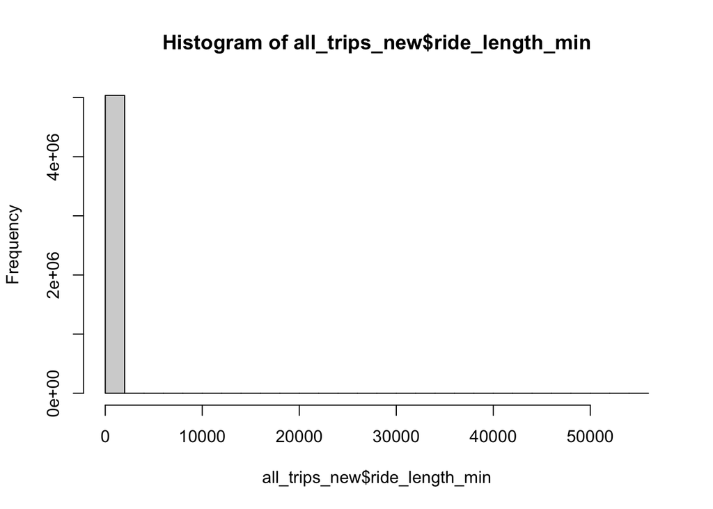

```r
hist(all_trips_new$ride_length_min)
```

#### Check from where the outliers are

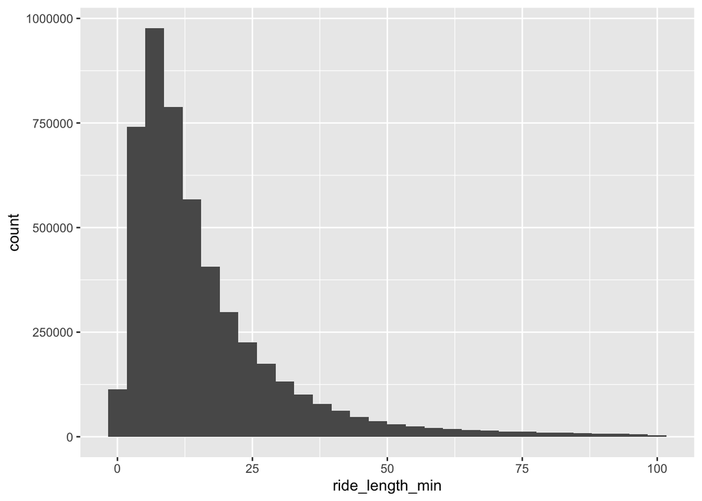

```r
all_trips_new %>%
  filter(all_trips_new$ride_length_min < 100) %>%
  ggplot(aes(x = ride_length_min)) + geom_histogram()
```

Seems like most of the ride length are under 100 min.

#### Subset table with ride length between 0-100 min

```r
all_trips_new2 <- subset(all_trips_new, ride_length_min >= 0 & ride_length_min <= 100)
```

#### Categorize ride length

```r
all_trips_new2 <- all_trips_new2 %>%
  mutate(ride_length_min_type = case_when(ride_length_min >= 0 & ride_length_min < 12 ~"0_to_12",
                                          ride_length_min >= 12 & ride_length_min < 25 ~"13_to_25",
                                          ride_length_min >= 25 & ride_length_min < 37 ~"25_to_37",
                                          ride_length_min >= 37 & ride_length_min < 50 ~"38_to_50",
                                          ride_length_min >= 50 & ride_length_min < 75 ~"50_to_75",
                                          ride_length_min >= 75 ~"over_75"))
```

#### Factor data

```r
all_trips_new2$day_of_week <- factor(all_trips_new2$day_of_week, levels = c("Monday", "Tuesday", "Wednesday", "Thursday", "Friday", "Saturday", "Sunday"))
all_trips_new2$section_of_day <- factor(all_trips_new2$section_of_day, levels = c("midnight", "dawn", "early_morning", "late_morning", "noon", "afternoon", "evening", "early_night", "late_night"))
```

#### Create another column with only weekday or weekend

```r
all_trips_new2 <- all_trips_new2 %>%
  mutate(weekday_weekend = case_when(day_of_week == "Monday" ~"weekday",
                                     day_of_week == "Tuesday" ~"weekday",
                                     day_of_week == "Wednesday" ~"weekday",
                                     day_of_week == "Thursday" ~"weekday",
                                     day_of_week == "Friday" ~"weekday",
                                     day_of_week == "Saturday" ~"weekend",
                                     day_of_week == "Sunday" ~"weekend"))
```

#### Create another column combining weekday of weekend, section of day

```r
all_trips_new2$ride_timing <- paste(all_trips_new2$weekday_weekend, all_trips_new2$section_of_day, sep = "_")
```

#### View and export table

```r
paged_table(head(all_trips_new2))
```

| ride_id | rideable_type | started_at | ended_at | start_station_name | start_station_id | end_station_name | end_station_id | member_casual | date | month | day | year | day_of_week | ride_length_min | hour_of_day | section_of_day | ride_length_min_type | weekday_weekend | ride_timing |
| --- | --- | --- | --- | --- | --- | --- | --- | --- | --- | --- | --- | --- | --- | --- | --- | --- | --- | --- | --- |
| EC2DE40644C6B0F4 | classic_bike | 2022-05-23 23:06:58 | 2022-05-23 23:40:19 | Wabash Ave & Grand Ave | TA1307000117 | Halsted St & Roscoe St | TA1309000025 | member | 2022-05-23 | 05 | 23 | 2022 | Monday | 33.350000 | 23 | late_night | 25_to_37 | weekday | weekday_late_night |
| 1C31AD03897EE385 | classic_bike | 2022-05-11 08:53:28 | 2022-05-11 09:31:22 | DuSable Lake Shore Dr & Monroe St | 13300 | Field Blvd & South Water St | 15534 | member | 2022-05-11 | 05 | 11 | 2022 | Wednesday | 37.900000 | 8 | early_morning | 38_to_50 | weekday | weekday_early_morning |
| 1542FBEC830415CF | classic_bike | 2022-05-26 18:36:28 | 2022-05-26 18:58:18 | Clinton St & Madison St | TA1305000032 | Wood St & Milwaukee Ave | 13221 | member | 2022-05-26 | 05 | 26 | 2022 | Thursday | 21.833333 | 18 | evening | 13_to_25 | weekday | weekday_evening |
| 6FF59852924528F8 | classic_bike | 2022-05-10 07:30:07 | 2022-05-10 07:38:49 | Clinton St & Madison St | TA1305000032 | Clark St & Randolph St | TA1305000030 | member | 2022-05-10 | 05 | 10 | 2022 | Tuesday | 8.700000 | 7 | early_morning | 0_to_12 | weekday | weekday_early_morning |
| 483C52CAAE12E3AC | classic_bike | 2022-05-10 17:31:56 | 2022-05-10 17:36:57 | Clinton St & Madison St | TA1305000032 | Morgan St & Lake St | TA1306000015 | member | 2022-05-10 | 05 | 10 | 2022 | Tuesday | 5.016667 | 17 | evening | 0_to_12 | weekday | weekday_evening |
| C0A3AA5A614DCE01 | classic_bike | 2022-05-04 14:48:55 | 2022-05-04 14:56:04 | Carpenter St & Huron St | 13196 | Sangamon St & Washington Blvd | 13409 | member | 2022-05-04 | 05 | 04 | 2022 | Wednesday | 7.150000 | 14 | afternoon | 0_to_12 | weekday | weekday_afternoon |

```r
write.csv(all_trips_new2, file = "~/Desktop/cyclistic/all_trips_new2.csv")
```

### Discriptive analysis cusual rider v.s. member

#### Check the distribution of casual rider and member

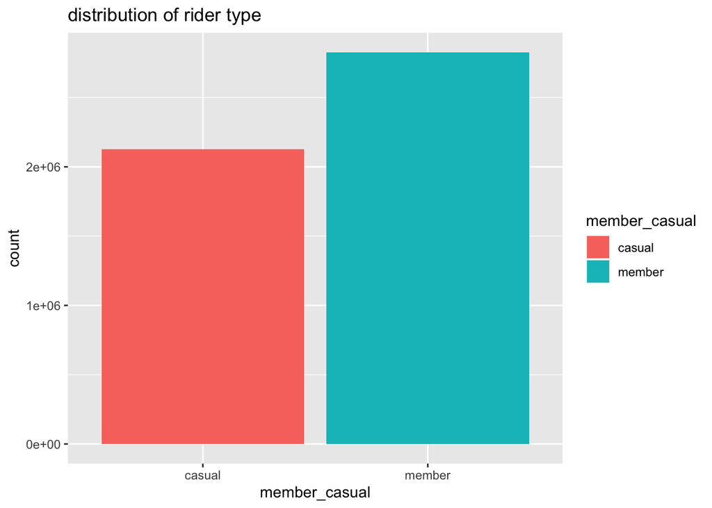

```r
ggplot(data = all_trips_new2) + geom_bar(mapping = aes(x = member_casual, fill = member_casual)) + labs(title = "distribution of rider type")
```

#### Check the barplot of other categorical columns

##### Bike type

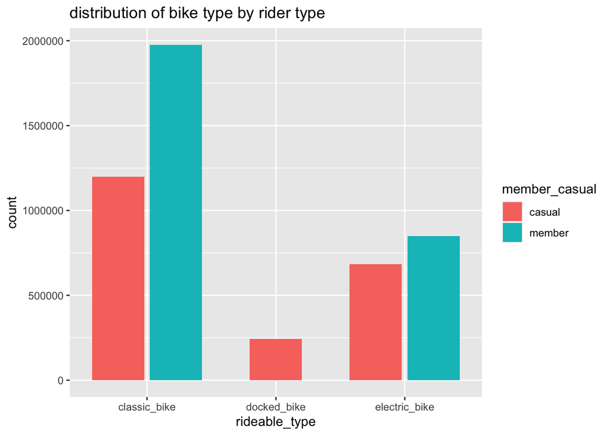

```r
ggplot(data = all_trips_new2) + geom_bar(position = position_dodge2(preserve = "single"), mapping = aes(x = rideable_type, fill = member_casual)) + labs(title = "distribution of bike type by rider type")
```

##### Month

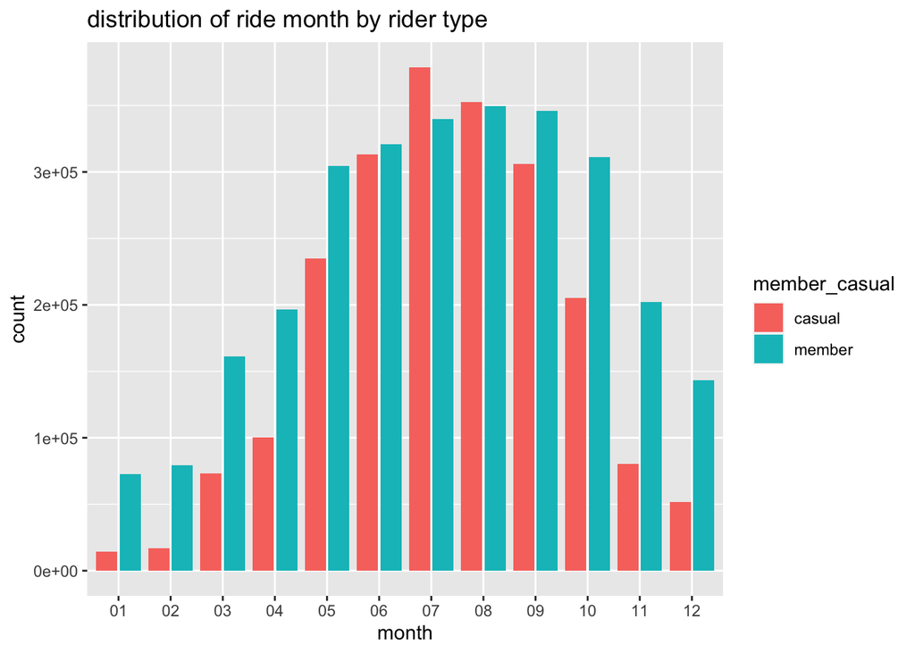

```r
ggplot(data = all_trips_new2) + geom_bar(position = position_dodge2(preserve = "single"), mapping = aes(x = month, fill = member_casual)) + labs(title = "distribution of ride month by rider type")
```

##### Day of week

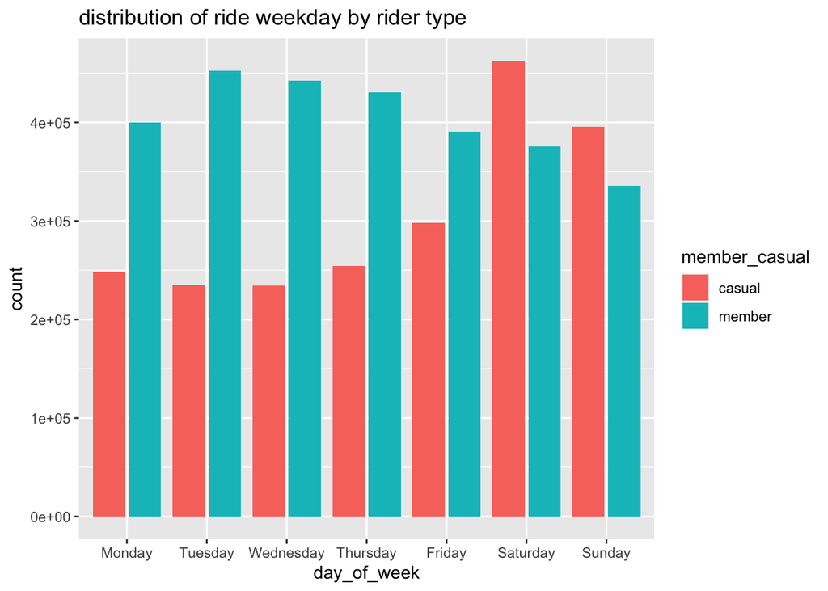

```r
ggplot(data = all_trips_new2) + geom_bar(position = position_dodge2(preserve = "single"), mapping = aes(x = day_of_week, fill = member_casual)) + labs(title = "distribution of ride weekday by rider type")
```

##### Section of day

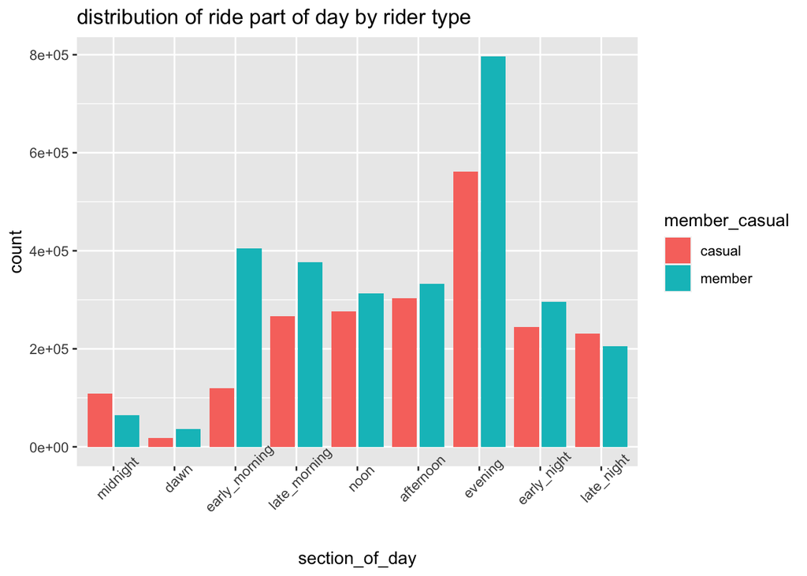

```r
ggplot(data = all_trips_new2) + geom_bar(position = position_dodge2(preserve = "single"), mapping = aes(x = section_of_day, fill = member_casual)) + labs(title = "distribution of ride part of day by rider type") + theme(axis.text.x = element_text(angle = 45))
```

##### Ride length in min

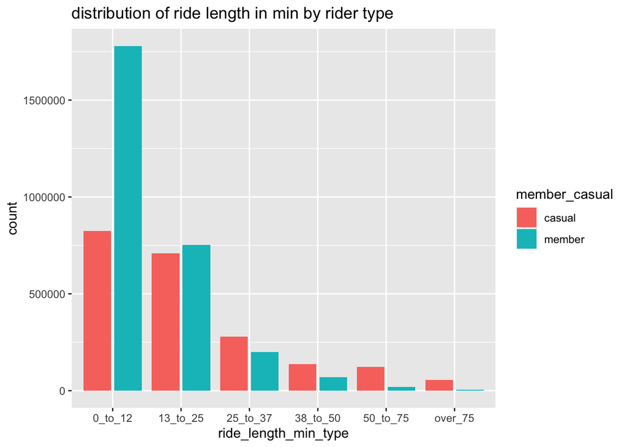

```r
ggplot(data = all_trips_new2) + geom_bar(position = position_dodge2(preserve = "single"), mapping = aes(x = ride_length_min_type, fill = member_casual)) + labs(title = "distribution of ride length in min by rider type")
```

For clearer overview of casual riders v.s. members, [see presentation p. 12-13](https://docs.google.com/presentation/d/1RtoUEgQbPs7Bj3rZnhTqfrNuq02_I-nhim4IrwTTFXI/edit?usp=sharing) (right click and open in browser)

### Exploratory analysis about casual riders

#### Subset a table with only casual riders

```r
all_trips_casual <- subset(all_trips_new2, member_casual=="casual")
```

#### Histogram of casual riders ride length

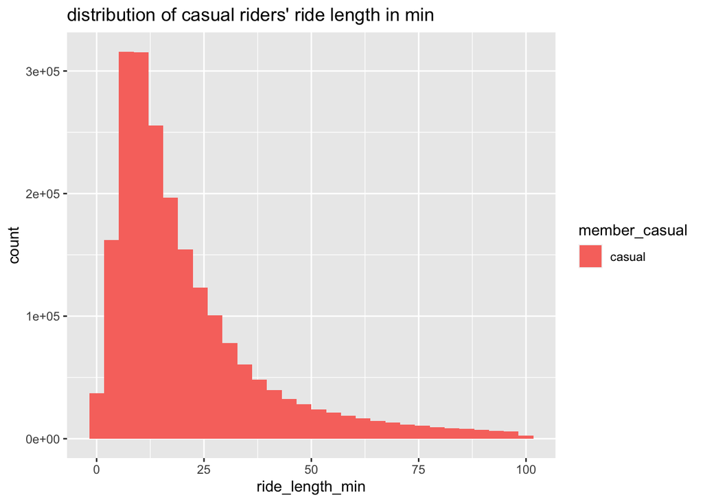

```r
ggplot(data = all_trips_casual) + geom_histogram(mapping = aes(x = ride_length_min, fill = member_casual)) + labs(title = "distribution of casual riders' ride length in min")
```

#### Summary statistics of casual riders ride length

```r
summary(all_trips_casual$ride_length_min)
```

```
##    Min. 1st Qu.  Median    Mean 3rd Qu.    Max.
##    0.00    8.80   15.18   21.14   26.98  100.00
```

#### Distribution of ride timing of casual riders

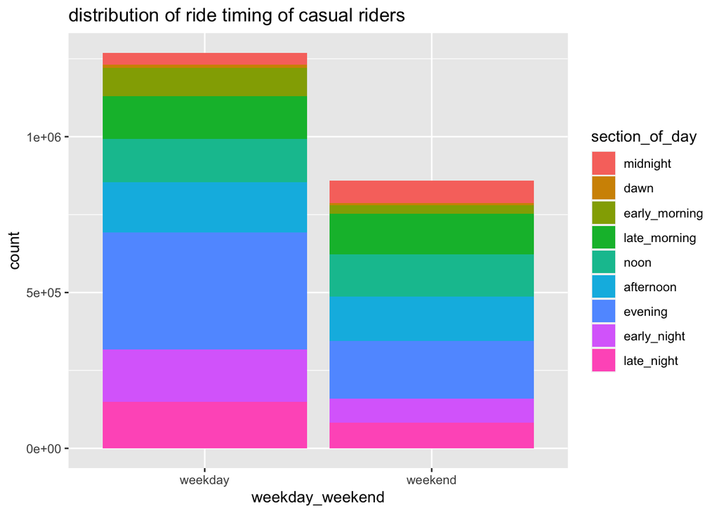

```r
ggplot(data = all_trips_casual) + geom_bar(mapping = aes(x = weekday_weekend, fill = section_of_day)) + labs(title = "distribution of ride timing of casual riders")
```

#### Distribution of ride timing of casual riders by month

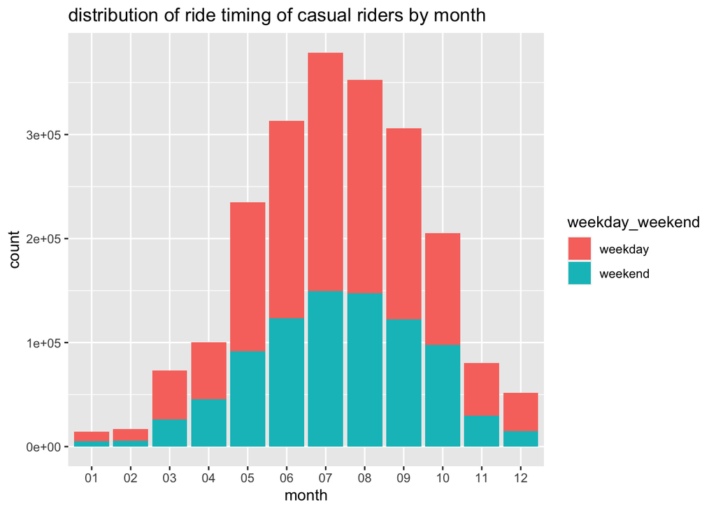

```r
ggplot(data = all_trips_casual) + geom_bar(mapping = aes(x = month, fill = weekday_weekend)) + labs(title = "distribution of ride timing of casual riders by month")
```

#### Distribution of ride timing by section of day of casual riders by month

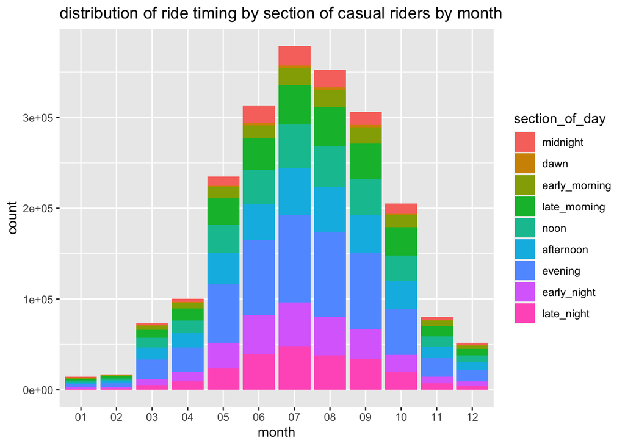

```r
ggplot(data = all_trips_casual) + geom_bar(mapping = aes(x = month, fill = section_of_day)) + labs(title = "distribution of ride timing by section of casual riders by month")
```

#### How the median of ride length per min changes through the week by month

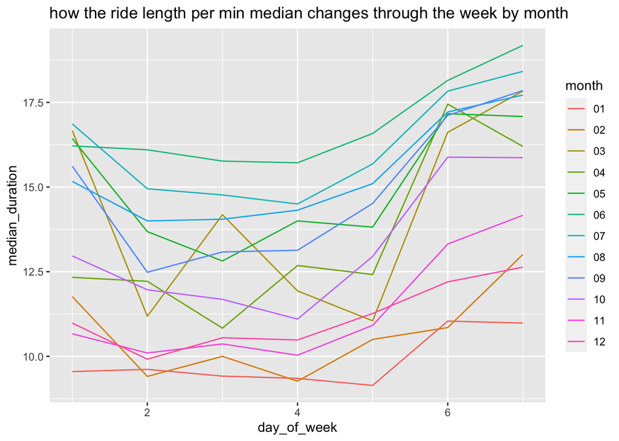

```r
all_trips_casual %>%
  mutate(day_of_week = case_when(day_of_week == "Monday" ~1,
                                     day_of_week == "Tuesday" ~2,
                                     day_of_week == "Wednesday" ~3,
                                     day_of_week == "Thursday" ~4,
                                     day_of_week == "Friday" ~5,
                                     day_of_week == "Saturday" ~6,
                                     day_of_week == "Sunday" ~7)) %>%
  group_by(day_of_week, month) %>%
  summarise(median_duration = median(ride_length_min)) %>%
  ggplot(aes(x = day_of_week, y = median_duration)) + geom_line(aes(colour = month)) + labs(title = "how the ride length per min median changes through the week by month")
```

Weekends the longest, then Monday, Wednesday increased a lot in march.

#### See how the ride length per min median changes hour per day by day of week

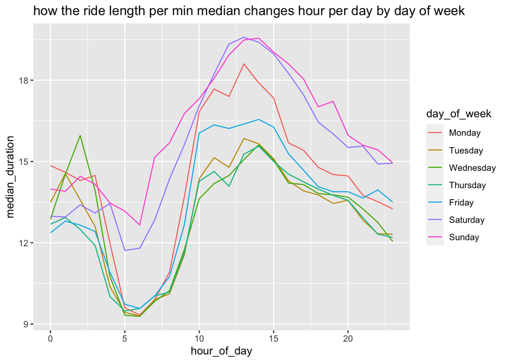

```r
all_trips_casual %>%
  group_by(hour_of_day, day_of_week) %>%
  summarise(median_duration = median(ride_length_min)) %>%
  ggplot(aes(x = hour_of_day, y = median_duration)) + geom_line(aes(colour = day_of_week)) + labs(title = "how the ride length per min median changes hour per day by day of week")
```

#### See how the ride length per min median changes hour per day by bike type

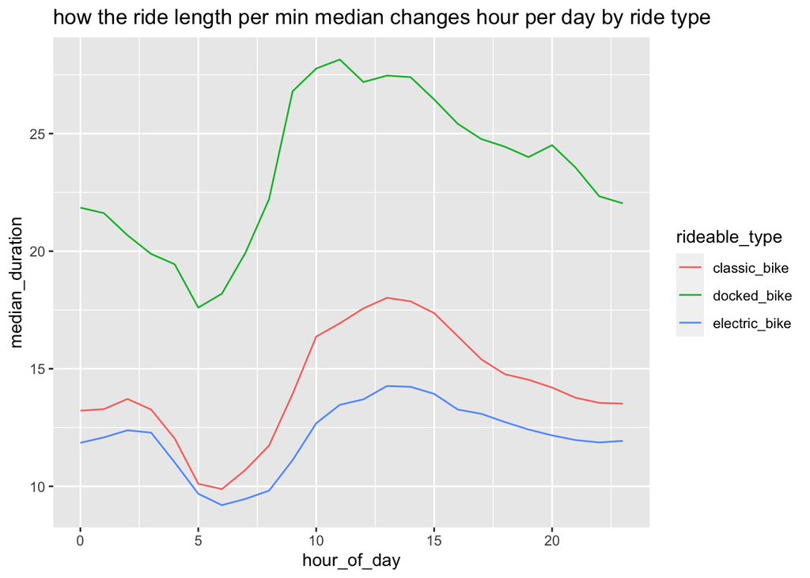

```r
all_trips_casual %>%
  group_by(hour_of_day, rideable_type) %>%
  summarise(median_duration = median(ride_length_min)) %>%
  ggplot(aes(x = hour_of_day, y = median_duration)) + geom_line(aes(colour = rideable_type)) + labs(title = "how the ride length per min median changes hour per day by ride type")
```

#### See how the median of ride length per min changes through the week by bike type

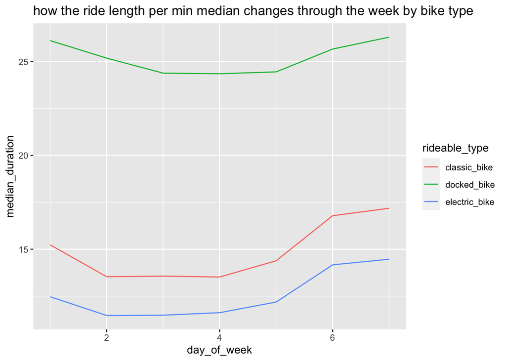

```r
all_trips_casual %>%
  mutate(day_of_week = case_when(day_of_week == "Monday" ~1,
                                 day_of_week == "Tuesday" ~2,
                                 day_of_week == "Wednesday" ~3,
                                 day_of_week == "Thursday" ~4,
                                 day_of_week == "Friday" ~5,
                                 day_of_week == "Saturday" ~6,
                                 day_of_week == "Sunday" ~7)) %>%
  group_by(day_of_week, rideable_type) %>%
  summarise(median_duration = median(ride_length_min)) %>%
  ggplot(aes(x = day_of_week, y = median_duration)) + geom_line(aes(colour = rideable_type)) + labs(title = "how the ride length per min median changes through the week by bike type")
```

#### About bike type

##### Bike type by day of week

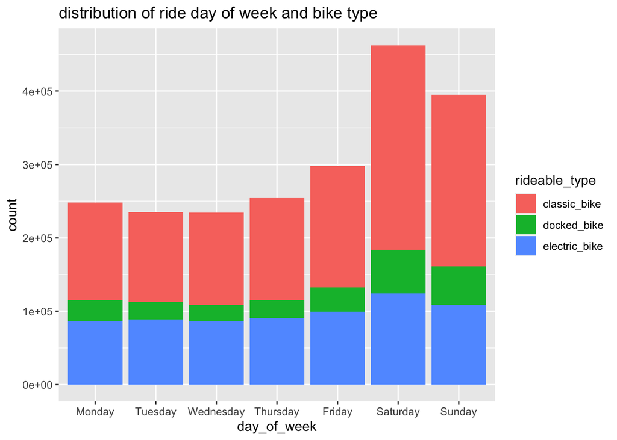

```r
ggplot(data = all_trips_casual) + geom_bar(mapping = aes(x = day_of_week, fill = rideable_type)) + labs(title = "distribution of ride day of week and bike type")
```

##### Bike type by section of day

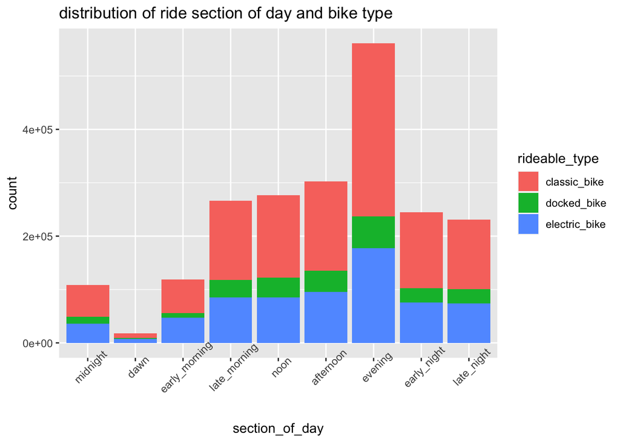

```r
ggplot(data = all_trips_casual) + geom_bar(mapping = aes(x = section_of_day, fill = rideable_type)) + labs(title = "distribution of ride section of day and bike type") + theme(axis.text.x = element_text(angle = 45))
```

##### Bike type by month

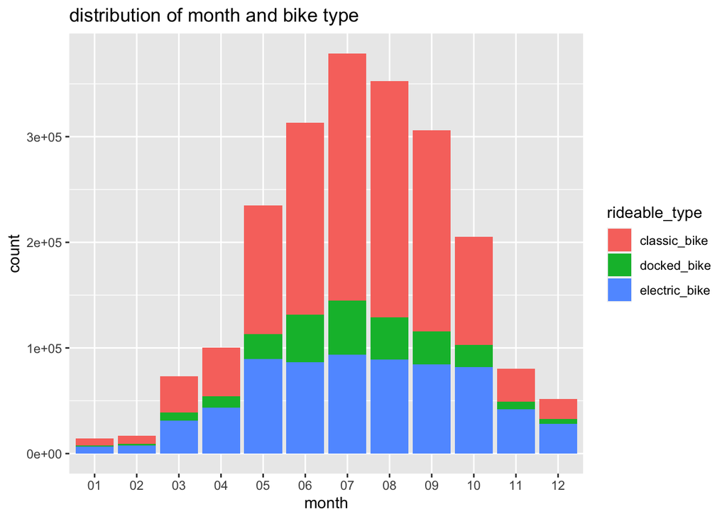

```r
ggplot(data = all_trips_casual) + geom_bar(mapping = aes(x = month, fill = rideable_type)) + labs(title = "distribution of month and bike type")
```

#### Export table

```r
write.csv(all_trips_casual, file = "~/Desktop/cyclistic/all_trips_casual.csv")
```

For clearer overview of exploratory anaysis of casual riders, [see presentation p. 14](https://docs.google.com/presentation/d/1RtoUEgQbPs7Bj3rZnhTqfrNuq02_I-nhim4IrwTTFXI/edit?usp=sharing) (right click and open in browser)

### Cluster analysis & classification

#### Cluster analysis

##### Subset a table with rideable_type, month, day_of_week, ride_length_min, hour_of_day

```r
casual_km <- subset(all_trips_casual, select = c(rideable_type, month, day_of_week, ride_length_min, hour_of_day))
```

##### Transfer month to numeric

```r
casual_km$month <- as.numeric(casual_km$month)
is.numeric(casual_km$month)
```

```
## [1] TRUE
```

##### Transfer month to numeric

Don’t need to scale because only ride_length_min is real numeric data.

##### Transfer categorical data in character to number and create reference table for later

```r
casual_km_matrix <- data.matrix(casual_km[c("rideable_type", "day_of_week")])
casual_km <- data.frame(casual_km, casual_km_matrix)
rideable_type_ref <- unique(casual_km[c("rideable_type", "rideable_type.1")])
day_of_week_ref <- unique(casual_km[c("day_of_week", "day_of_week.1")])
write.csv(day_of_week_ref, file = "~/Desktop/cyclistic/day_of_week_ref.csv")
write.csv(rideable_type_ref, file = "~/Desktop/cyclistic/rideable_type_ref.csv")
```

Since there are both numerical and categorical variables, so use PAM clustering with gower distance and silhouette method.

##### Table with only the columns for PAM

```r
casual_pam <- subset(casual_km, select = c(rideable_type.1, month, day_of_week.1, ride_length_min, hour_of_day))
```

##### Sample the data smaller to run the function and export table

```r
casual_pam_sample <- casual_pam[sample(1:nrow(casual_pam), size = 5000), ]
write.csv(casual_pam_sample, file = "~/Desktop/cyclistic/casual_pam_sample.csv")
```

##### Gower distance table

```r
casual_gower_mat <- daisy(casual_pam_sample, metric = "gower")
```

##### Find out how many cluster with silhouette method

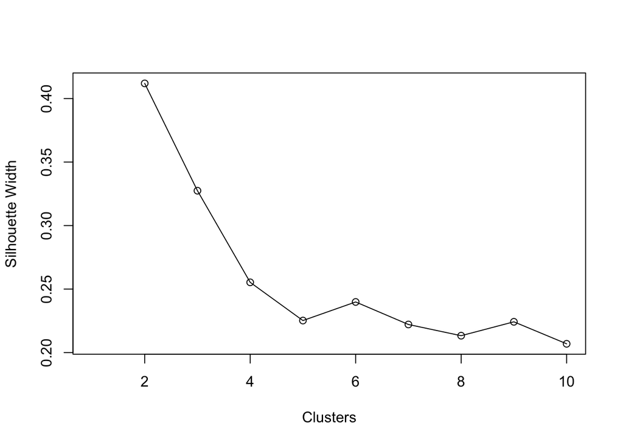

```r
silhouette <- c()
silhouette = c(silhouette, NA)
for(i in 2:10){
  pam_clusters = pam(as.matrix(casual_gower_mat),
                     diss = TRUE,
                     k = i)
  silhouette = c(silhouette ,pam_clusters$silinfo$avg.width)
}
plot(1:10, silhouette,
     xlab = "Clusters",
     ylab = "Silhouette Width")
lines(1:10, silhouette)
```

**2 clusters**

##### Run PAM

```r
set.seed(105)
pam_casual <- pam(x = casual_gower_mat, k = 2, diss = TRUE, nstart = 25)
pam_casual
```

```
## Medoids:
##      ID
## [1,] "2534" "1105651"
## [2,] "3385" "1792162"
## Clustering vector:
##  484723  944690  263038 1281745  585676 1710549 1683773 1170171 1340415 1758250
##       1       2       1       2       1       2       2       2       2       2
## 1908258  558067 1471141 1913808  370955  100834 1738225 1269578 1014999 1935874
##       2       1       2       2       2       2       2       2       2       1
##    7002 1961259   91154  433265   61394 2071803 1987593  676686 1169870  290964
##       2       1       1       2       2       1       2       1       2       2
##   45630 1081156  342629  220541 1055952 1671890 1026574 1530931 2035862 1383463
##       1       2       2       1       2       1       1       2       2       2
##  583120   67588  799072  796696 1103286 2072145  812290  356112 1086221 1900061
##       1       2       2       2       2       2       1       2       2       2
```

[output cut: 997 more lines]

##### Plot cluster result

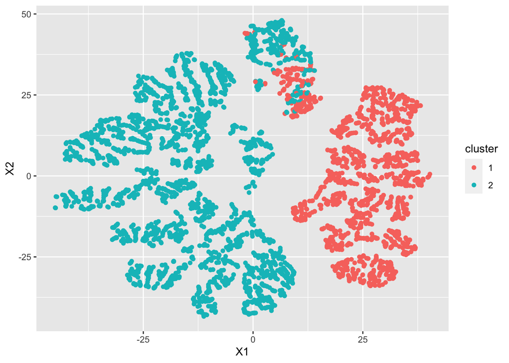

```r
tsne_object <- Rtsne(casual_gower_mat, is_distance = TRUE)
tsne_df <- data.frame(tsne_object$Y)
tsne_df$cluster = factor(pam_casual$clustering)
ggplot(aes(x = X1, y = X2), data = tsne_df) + geom_point(aes(color = cluster))
```

Even if there are 300 iterations, there is a bit overlapping, however, the medoids are far away.

##### Label the rows with their cluster numbers

```r
casual_pam_sample$cluster <- pam_casual$clustering
```

##### Check the info about each cluster

```r
casual_pam_sample[pam_casual$medoids, ]
```

```
##         rideable_type.1 month day_of_week.1 ride_length_min hour_of_day cluster
## 1105651               3     8             4           10.90          14       1
## 1792162               1     7             5           19.95          16       2
```

##### View and export table

```r
paged_table(head(casual_pam_sample))
```

|  | rideable_type.1 | month | day_of_week.1 | ride_length_min | hour_of_day | cluster |
| --- | --- | --- | --- | --- | --- | --- |
| 484723 | 3 | 12 | 5 | 31.133333 | 14 | 1 |
| 944690 | 1 | 9 | 3 | 24.733333 | 17 | 2 |
| 263038 | 3 | 4 | 2 | 13.300000 | 13 | 1 |
| 1281745 | 1 | 8 | 3 | 19.733333 | 21 | 2 |
| 585676 | 2 | 10 | 1 | 18.600000 | 16 | 1 |
| 1710549 | 1 | 7 | 6 | 2.616667 | 19 | 2 |

```r
write.csv(casual_pam_sample, file = "~/Desktop/cyclistic/casual_pam_sample.csv")
```

#### Classify all casual riders to clusters with random forest model

##### Create a new column for character cluster

```r
casual_rfm <- casual_pam_sample %>%
  mutate(cluster_ch = case_when(cluster == 1 ~"cluster_1",
                                cluster == 2 ~"cluster_2"))
```

##### Convert character to factor

```r
casual_rfm$cluster_ch <- as.factor(casual_rfm$cluster_ch)
casual_rfm <- droplevels(casual_rfm)
```

##### Export table

```r
write.csv(casual_rfm, file = "~/Desktop/cyclistic/casual_rfm.csv")
```

##### Split data and test accuracy

```r
casual_rfm_index <- sample(2, nrow(casual_rfm), replace = TRUE, prob = c(0.7, 0.3))
casual_rfm_training <- casual_rfm[casual_rfm_index == 1, ]
casual_rfm_testing <- casual_rfm[casual_rfm_index == 2, ]
casual_rfm_test_run <- randomForest(cluster_ch~rideable_type.1+month+day_of_week.1+ride_length_min+hour_of_day, data = casual_rfm_training)
casaul_test_pred <- predict(casual_rfm_test_run, casual_rfm_testing)
casual_rfm_testing$cluster_pred <- casaul_test_pred
abc <- table(casual_rfm_testing$cluster_ch, casual_rfm_testing$cluster_pred)
accuracy <- sum(diag(abc)/sum(abc))
```

Accuracy (57%) is not high enough, for now just use the full data to increase accuracy (there’s actually not that big of a difference between two clusters, and both clusters already share the same possible problems, the classification is just to see how to communicate more individually to each cluster, so the accuracy can be improved later. Just wanna see the start and end station).

##### Run random forest

```r
casual_rfm_run <- randomForest(cluster_ch~rideable_type.1+month+day_of_week.1+ride_length_min+hour_of_day, data = casual_rfm)
```

##### Prepare the table, in which the clusters should be predicted

```r
casual_predict_cluster <- subset(all_trips_casual, select = c(start_station_name, end_station_name))
casual_predict_cluster$number <- 1:nrow(casual_predict_cluster)
casual_km_new <- read_csv("cyclistic/casual_km_new.csv")
```

```
## ──────────────────────────────────────────────────────── Delimiter: "," dbl
## (6): ...1, rideable_type.1, month, day_of_week.1, ride_length_min, hour_...
```

```r
casual_km_new$number <- 1:nrow(casual_km_new)
casual_predict_cluster <- merge(casual_predict_cluster, casual_km_new, by = "number")
casual_predict_cluster <- casual_predict_cluster[-1]
casual_predict_cluster <- casual_predict_cluster[-3]
```

##### Predict

```r
casual_predict_cluster$predicted_cluster <- predict(casual_rfm_run, casual_predict_cluster, interval = "confidence", level = 0.95)
```

##### View and export table

```r
paged_table(head(casual_predict_cluster))
```

|  | start_station_name | end_station_name | rideable_type.1 | month | day_of_week.1 | ride_length_min | hour_of_day | predicted_cluster |
| --- | --- | --- | --- | --- | --- | --- | --- | --- |
| 1 | Halsted St & Wrightwood Ave | Southport Ave & Clybourn Ave | 2 | 5 | 7 | 12.166667 | 19 | cluster_2 |
| 2 | Clark St & Newport St | Racine Ave & Wrightwood Ave | 1 | 5 | 2 | 7.916667 | 9 | cluster_2 |
| 3 | Sedgwick St & North Ave | Wood St & Milwaukee Ave | 1 | 5 | 7 | 29.883333 | 12 | cluster_2 |
| 4 | Canal St & Jackson Blvd | Canal St & Taylor St | 3 | 5 | 5 | 5.800000 | 10 | cluster_1 |
| 5 | Hoyne Ave & Balmoral Ave | Broadway & Thorndale Ave | 1 | 5 | 7 | 13.750000 | 14 | cluster_2 |
| 6 | Clark St & Elmdale Ave | Broadway & Argyle St | 3 | 5 | 5 | 11.966667 | 8 | cluster_1 |

```r
write.csv(casual_predict_cluster, file = "~/Desktop/cyclistic/casual_predict_cluster.csv")
```

For clearer overview of cluster anaysis and classification of casual riders, [see presentation p. 15-16](https://docs.google.com/presentation/d/1RtoUEgQbPs7Bj3rZnhTqfrNuq02_I-nhim4IrwTTFXI/edit?usp=sharing) (right click and open in browser)

### Prepare table for bi

#### Change the categorical numbers to characters

```r
casual_bi_table <- casual_predict_cluster %>%
  mutate(bike_type = case_when(rideable_type.1 == 1 ~"classic_bike",
                               rideable_type.1 == 2 ~"docked_bike",
                               rideable_type.1 == 3 ~"electric_bike" ))

casual_bi_table <- casual_bi_table %>%
  mutate(month_ch = case_when(month == 1 ~"Jan",
                               month == 2 ~"Feb",
                               month == 3 ~"Mar",
                               month == 4 ~"Apr",
                               month == 5 ~"May",
                               month == 6 ~"Jun",
                               month == 7 ~"Jul",
                               month == 8 ~"Aug",
                               month == 9 ~"Sep",
                               month == 10 ~"Oct",
                               month == 11 ~"Nov",
                               month == 12 ~"Dec"))

casual_bi_table <- casual_bi_table %>%
  mutate(day = case_when(day_of_week.1 == 1 ~"Monday",
                         day_of_week.1 == 2 ~"Tuesday",
                         day_of_week.1 == 3 ~"Wednesday",
                         day_of_week.1 == 4 ~"Thursday",
                         day_of_week.1 == 5 ~"Friday",
                         day_of_week.1 == 6 ~"Saturday",
                         day_of_week.1 == 7 ~"Sunday"))

casual_bi_table <- casual_bi_table %>%
  mutate(section_of_day = case_when(hour_of_day >= 0 & hour_of_day < 4 ~"midnight",
                                    hour_of_day >= 4 & hour_of_day < 6 ~"dawn",
                                    hour_of_day >= 6 & hour_of_day < 9 ~"early_morning",
                                    hour_of_day >= 9 & hour_of_day < 12 ~"late_morning",
                                    hour_of_day >= 12 & hour_of_day < 14 ~"noon",
                                    hour_of_day >= 14 & hour_of_day < 16 ~"afternoon",
                                    hour_of_day >= 16 & hour_of_day < 19 ~"evening",
                                    hour_of_day >= 19 & hour_of_day < 21 ~"early_night",
                                    hour_of_day >= 21 ~"late_night"))

casual_bi_table <- casual_bi_table %>%
  mutate(ride_minutes = case_when(ride_length_min >= 0 & ride_length_min < 12 ~"0_to_12",
                                          ride_length_min >= 12 & ride_length_min < 25 ~"13_to_25",
                                          ride_length_min >= 25 & ride_length_min < 37 ~"25_to_37",
                                          ride_length_min >= 37 & ride_length_min < 50 ~"38_to_50",
                                          ride_length_min >= 50 & ride_length_min < 75 ~"50_to_75",
                                          ride_length_min >= 75 ~"over_75"))
```

#### Remove unused columns and check NA values

```r
casual_bi_table <- subset(casual_bi_table, select = -c(rideable_type.1, month, day_of_week.1))
colSums(is.na(casual_bi_table))
```

```
## start_station_name   end_station_name    ride_length_min        hour_of_day
##                  0             177925                  0                  0
##  predicted_cluster          bike_type           month_ch                day
##                  0                  0                  0                  0
##     section_of_day       ride_minutes
##                  0                  0
```

**Reminds me of the bikes that are probably not returned.**

#### Create a column to address this problem and check the column

```r
casual_bi_table <- casual_bi_table %>%
  mutate(end_station_name = coalesce(end_station_name, "none"))
casual_bi_table$returned[casual_bi_table$end_station_name == "none"] <- "not_returned"
casual_bi_table <- casual_bi_table %>%
  mutate(returned = coalesce(returned, "returned"))
table(casual_bi_table$returned)
```

```
##
## not_returned     returned
##       177925      1949474
```

#### Factor the data

```r
casual_bi_table$month_ch <- factor(casual_bi_table$month_ch, levels = c("Jan", "Feb", "Mar", "Apr", "May", "Jun", "Jul", "Aug", "Sep", "Oct", "Nov", "Dec"))
casual_bi_table$day <- factor(casual_bi_table$day, levels = c("Monday", "Tuesday", "Wednesday", "Thursday", "Friday", "Saturday", "Sunday"))
casual_bi_table$section_of_day <- factor(casual_bi_table$section_of_day, levels = c("midnight", "dawn", "early_morning", "late_morning", "noon", "afternoon", "evening", "early_night", "late_night"))
casual_bi_table$ride_minutes <- factor(casual_bi_table$ride_minutes, levels = c("0_to_12", "13_to_25", "25_to_37", "38_to_50", "50_to_75", "over_75"))
```

#### View and export table

```r
paged_table(head(casual_bi_table))
```

|  | start_station_name | end_station_name | ride_length_min | hour_of_day | predicted_cluster | bike_type | month_ch | day | section_of_day | ride_minutes | returned |
| --- | --- | --- | --- | --- | --- | --- | --- | --- | --- | --- | --- |
| 1 | Halsted St & Wrightwood Ave | Southport Ave & Clybourn Ave | 12.166667 | 19 | cluster_2 | docked_bike | May | Sunday | early_night | 13_to_25 | returned |
| 2 | Clark St & Newport St | Racine Ave & Wrightwood Ave | 7.916667 | 9 | cluster_2 | classic_bike | May | Tuesday | late_morning | 0_to_12 | returned |
| 3 | Sedgwick St & North Ave | Wood St & Milwaukee Ave | 29.883333 | 12 | cluster_2 | classic_bike | May | Sunday | noon | 25_to_37 | returned |
| 4 | Canal St & Jackson Blvd | Canal St & Taylor St | 5.800000 | 10 | cluster_1 | electric_bike | May | Friday | late_morning | 0_to_12 | returned |
| 5 | Hoyne Ave & Balmoral Ave | Broadway & Thorndale Ave | 13.750000 | 14 | cluster_2 | classic_bike | May | Sunday | afternoon | 13_to_25 | returned |
| 6 | Clark St & Elmdale Ave | Broadway & Argyle St | 11.966667 | 8 | cluster_1 | electric_bike | May | Friday | early_morning | 0_to_12 | returned |

```r
write.csv(casual_bi_table, file = "~/Desktop/cyclistic/casual_bi_table.csv")
```

#### Sample a smaller table for BI, so data won’t be excluded improperly

```r
casual_bi_table_small <- casual_bi_table[sample(1:nrow(casual_bi_table), size = 1000000), ]
```

#### Make sure all months are included

```r
table(casual_bi_table_small$month_ch)
```

```
##
##    Jan    Feb    Mar    Apr    May    Jun    Jul    Aug    Sep    Oct    Nov
##   6796   7889  34293  47324 110330 147329 178031 165735 144086  96470  37594
##    Dec
##  24123
```

Yes.

#### Export table

```r
write.csv(casual_bi_table_small, file = "~/Desktop/cyclistic/casual_bi_table_small.csv")
```

[See cluster dashboard](https://app.powerbi.com/view?r=eyJrIjoiOWNiZGQxNDAtOGY4My00YWQxLTllNGItNTFhNDBjOTdjNWZhIiwidCI6ImEzMjZjMjU3LWQ5ZmUtNGI5OS04MzJlLWJlNmExZWI2MTNlYSIsImMiOjEwfQ%3D%3D)

## Conclusion

Casual riders may face a lot of problems when docking the e-bikes, so they struggle and complain on social media. That is a chance for Cyclistic to make them join memberships. But it can only become a chance if the memberships can solve their problems. “E-bike memberships” are memberships that would do.There are several ways to communicate the benefits of “E-bike memberships” to them using digital/online marketing. Three of the ways would be :  
* Social media ads : Solve pain points + convey “convenient, affordable, fun/healthy”  
* Dialog in the app : Solve pain points + convey “convenient”  
* Koc hashtag or tiktok : Attract with interesting thing + convey “fun/healthy”

**To see more detailed explanation about the pain points, e-bike membership and the visualization of the 3 digital/online marketing ways, [see presentation p. 17-26](https://docs.google.com/presentation/d/1RtoUEgQbPs7Bj3rZnhTqfrNuq02_I-nhim4IrwTTFXI/edit?usp=sharing) (right click and open in browser)**

To improve classification accuracy, I could analyze more data about person, like gender, age, family status, income… etc.

To look more into what is influencing the ride length in different timing, I could analyze more marketing data, like events, campaigns… etc.

**Thank you and have a nice day.**